# Decision Tree using Caret Package

Kumar Rahul

9 September 2016

There are bugs/missing code in the entire exercise. The participants are expected to work upon them.

## Here are some useful links:

> 1. **[Read](http://www.ats.ucla.edu/stat/mult_pkg/faq/general/dummy.htm)** about interaction variable coding
> 2. Refer **[link](http://www.statmethods.net/input/valuelabels.html)** to know about adding lables to factors
> 3. Refer **[link](http://stackoverflow.com/questions/2342472/recode-relevel-data-frame-factors-with-different-levels)** to relvel factor variables
> 4. **[Read](http://stats.stackexchange.com/questions/88485/variable-is-significant-through-stepwise-regression-but-not-in-final-models-sum)** about the issues in stepwise regression
> 5. **[Read](http://topepo.github.io/caret/training.html)** about the modelling activity via caret package
> 6. The **[complete](http://topepo.github.io/caret/available-models.html)** list of tuning parameter for different models in caret package

# Code starts here

```r
library(caret)    #for data partition. Model building
#library(Deducer) #for ROC plot
library(ROCR)     #for ROC plot (other way)
#library(rattle)   #for plotting tree
library(rpart)
```

## Data Import and Manipulation

### 1. Importing a data set

*Give the correct path to the data*

```r
raw_df <- read.csv("/Users/Rahul/Documents/Datasets/IMB533_HR_Data_No_Missing_Value.csv",
    header = TRUE, sep = ",", na.strings = c("", " ", "NA"))
```

Note that `echo = FALSE` parameter prevents printing the R code that generated the plot.

### 2. Structure and Summary of the dataset

```r
str(raw_df)
```

```
## 'data.frame':    8995 obs. of  18 variables:
##  $ SLNO                       : int  1 2 3 4 5 6 7 9 11 12 ...
##  $ Candidate.Ref              : int  2110407 2112635 2112838 2115021 2115125 2117167 2119124 2127572 2138169 2143362 ...
##  $ DOJ.Extended               : Factor w/ 2 levels "No","Yes": 2 1 1 1 2 2 2 2 1 1 ...
##  $ Duration.to.accept.offer   : int  14 18 3 26 1 17 37 16 1 6 ...
##  $ Notice.period              : int  30 30 45 30 120 30 30 0 30 30 ...
##  $ Offered.band               : Factor w/ 4 levels "E0","E1","E2",..: 3 3 3 3 3 2 3 2 2 2 ...
##  $ Pecent.hike.expected.in.CTC: num  -20.8 50 42.8 42.8 42.6 ...
##  $ Percent.hike.offered.in.CTC: num  13.2 320 42.8 42.8 42.6 ...
##  $ Percent.difference.CTC     : num  42.9 180 0 0 0 ...
##  $ Joining.Bonus              : Factor w/ 2 levels "No","Yes": 1 1 1 1 1 1 1 1 1 1 ...
##  $ Candidate.relocate.actual  : Factor w/ 2 levels "No","Yes": 1 1 1 1 2 1 1 1 1 1 ...
##  $ Gender                     : Factor w/ 2 levels "Female","Male": 1 2 2 2 2 2 2 1 1 2 ...
##  $ Candidate.Source           : Factor w/ 3 levels "Agency","Direct",..: 1 3 1 3 3 3 3 2 3 3 ...
##  $ Rex.in.Yrs                 : int  7 8 4 4 6 2 7 8 3 3 ...
##  $ LOB                        : Factor w/ 9 levels "AXON","BFSI",..: 5 8 8 8 8 8 8 7 2 3 ...
##  $ Location                   : Factor w/ 11 levels "Ahmedabad","Bangalore",..: 9 3 9 9 9 9 9 9 5 3 ...
##  $ Age                        : int  34 34 27 34 34 34 32 34 26 34 ...
##  $ Status                     : Factor w/ 2 levels "Joined","Not Joined": 1 1 1 1 1 1 1 1 1 1 ...
```

```r
summary(raw_df)
```

```
##       SLNO       Candidate.Ref     DOJ.Extended Duration.to.accept.offer
##  Min.   :    1   Min.   :2109586   No :4788     Min.   :  0.00
##  1st Qu.: 3208   1st Qu.:2386476   Yes:4207     1st Qu.:  3.00
##  Median : 5976   Median :2807482                Median : 10.00
##  Mean   : 5971   Mean   :2843647                Mean   : 21.43
##  3rd Qu.: 8739   3rd Qu.:3300060                3rd Qu.: 33.00
##  Max.   :12333   Max.   :3836076                Max.   :224.00
##
##  Notice.period    Offered.band Pecent.hike.expected.in.CTC
##  Min.   :  0.00   E0: 211      Min.   :-68.83
##  1st Qu.: 30.00   E1:5568      1st Qu.: 27.27
##  Median : 30.00   E2:2711      Median : 40.00
##  Mean   : 39.29   E3: 505      Mean   : 43.86
##  3rd Qu.: 60.00                3rd Qu.: 53.85
##  Max.   :120.00                Max.   :359.77
##
##  Percent.hike.offered.in.CTC Percent.difference.CTC Joining.Bonus
##  Min.   :-60.53              Min.   :-67.270        No :8578
##  1st Qu.: 22.09              1st Qu.: -8.330        Yes: 417
##  Median : 36.00              Median :  0.000
##  Mean   : 40.66              Mean   : -1.574
##  3rd Qu.: 50.00              3rd Qu.:  0.000
##  Max.   :471.43              Max.   :300.000
##
##  Candidate.relocate.actual    Gender              Candidate.Source
##  No :7705                  Female:1551   Agency           :2585
##  Yes:1290                  Male  :7444   Direct           :4801
##                                          Employee Referral:1609
##
##
##
##
##    Rex.in.Yrs          LOB            Location         Age
##  Min.   : 0.000   INFRA  :2850   Chennai  :3150   Min.   :20.00
##  1st Qu.: 3.000   ERS    :2426   Noida    :2727   1st Qu.:27.00
##  Median : 4.000   BFSI   :1396   Bangalore:2230   Median :29.00
##  Mean   : 4.239   ETS    : 691   Hyderabad: 341   Mean   :29.91
##  3rd Qu.: 6.000   CSMP   : 579   Mumbai   : 197   3rd Qu.:34.00
##  Max.   :24.000   AXON   : 568   Gurgaon  : 146   Max.   :60.00
##                   (Other): 485   (Other)  : 204
##         Status
##  Joined    :7313
##  Not Joined:1682
##
##
##
##
##
```

Create a new data frame and store the raw data copy. This is being done to have a copy of the raw data intact for further manipulation if needed.

```r
filter_df <- na.omit(raw_df)  # listwise deletion of missing
```

### 3. Create train and test dataset

#### Reserve 80% for *training* and 20% of *test*

*Correct the error in the below code chunk*

```r
set.seed(2341)
trainIndex <- createDataPartition(filter_df$Status, p = 0.8, list = FALSE)
train_df <- filter_df[trainIndex, ]
test_df <- filter_df[-trainIndex, ]
```

We can pull the specific attribute needed to build the model is another data frame. This agian is more of a hygine practice to not touch the **train** and **test** data set directly.

```r
dt_train_df <- as.data.frame(train_df[, c("DOJ.Extended", "Duration.to.accept.offer",
    "Notice.period", "Offered.band", "Percent.difference.CTC", "Joining.Bonus",
    "Gender", "Candidate.Source", "Rex.in.Yrs", "LOB", "Location", "Age", "Status")])
```

```r
dt_test_data <- as.data.frame(test_df[, c("DOJ.Extended", "Duration.to.accept.offer",
    "Notice.period", "Offered.band", "Percent.difference.CTC", "Joining.Bonus",
    "Gender", "Candidate.Source", "Rex.in.Yrs", "LOB", "Location", "Age", "Status")])
```

## Model Building: Using the **caret()** package

The below chunk of code is standarized way of building model using caret package. Setting in the control parameters for the model.

```r
objControl <- trainControl(method = "cv", number = 2,
                           summaryFunction = twoClassSummary,
                           classProbs = TRUE,
                           sampling = 'down',
                           savePredictions = TRUE)
```

Using search grid to fine tune the model

```r
search_grid <- expand.grid(cp=seq(0.001,0.02, 0.001))
```

The model building starts here. > 1. **metric= “ROC”** uses ROC curve to select the best model.Accuracy, Kappa are other options. To use this change twoClassSummary to defaultSummary in **ObjControl** 2. **verbose = FALSE**: does not show the processing output on console

The factor names at times may not be consistent. R may expect **“Not.Joined”** but the actual level may be **“Not Joined”** This is corrected by using **make.names()** function to give syntactically valid names. Type ?rpart.control in console to get the list of parameters which control the tree growth.

```r
#dt_train_df$StatusFactor <- as.factor(ifelse(dt_train_df$Status == "Joined", 1,0))
set.seed(766)
levels(dt_train_df$Status) <- make.names(levels(factor(dt_train_df$Status)))
formula <- as.formula(Status~.)

dt_caret_model <- caret:::train.formula(formula,
                     dt_train_df,
                     method = 'rpart',
                     minsplit = 100,
                     maxdepth = 4,
                     metric = "ROC",
                     tuneLength = 10,
                     trControl = objControl
                     #tuneGrid = search_grid
                     )

dt_caret_model
```

```
## CART
##
## 7197 samples
##   12 predictor
##    2 classes: 'Joined', 'Not.Joined'
##
## No pre-processing
## Resampling: Cross-Validated (2 fold)
## Summary of sample sizes: 3599, 3598
## Addtional sampling using down-sampling
##
## Resampling results across tuning parameters:
##
##   cp           ROC        Sens       Spec
##   0.001671620  0.6459424  0.6267306  0.5988113
##   0.001857355  0.6459424  0.6267306  0.5988113
##   0.001981179  0.6486651  0.6306623  0.5980684
##   0.002228826  0.6431383  0.6140895  0.6233284
##   0.002600297  0.6394232  0.6062269  0.6329866
##   0.002971768  0.6414317  0.6058851  0.6344725
##   0.003343239  0.6414317  0.6058851  0.6344725
##   0.003714710  0.6427032  0.6130598  0.6367013
##   0.005200594  0.6480660  0.6176765  0.6255572
##   0.006368075  0.6537471  0.6605846  0.5638930
##
## ROC was used to select the optimal model using the largest value.
## The final value used for the model was cp = 0.006368075.
```

Business rules from the tree.

```r
dt_caret_model$finalModel
```

```
## n= 2692
##
## node), split, n, loss, yval, (yprob)
##       * denotes terminal node
##
## 1) root 2692 1346 Joined (0.5000000 0.5000000)
##   2) Notice.period< 37.5 1602  643 Joined (0.5986267 0.4013733)
##     4) Duration.to.accept.offer< 74.5 1545  595 Joined (0.6148867 0.3851133) *
##     5) Duration.to.accept.offer>=74.5 57    9 Not.Joined (0.1578947 0.8421053) *
##   3) Notice.period>=37.5 1090  387 Not.Joined (0.3550459 0.6449541) *
```

Visualize the rules.

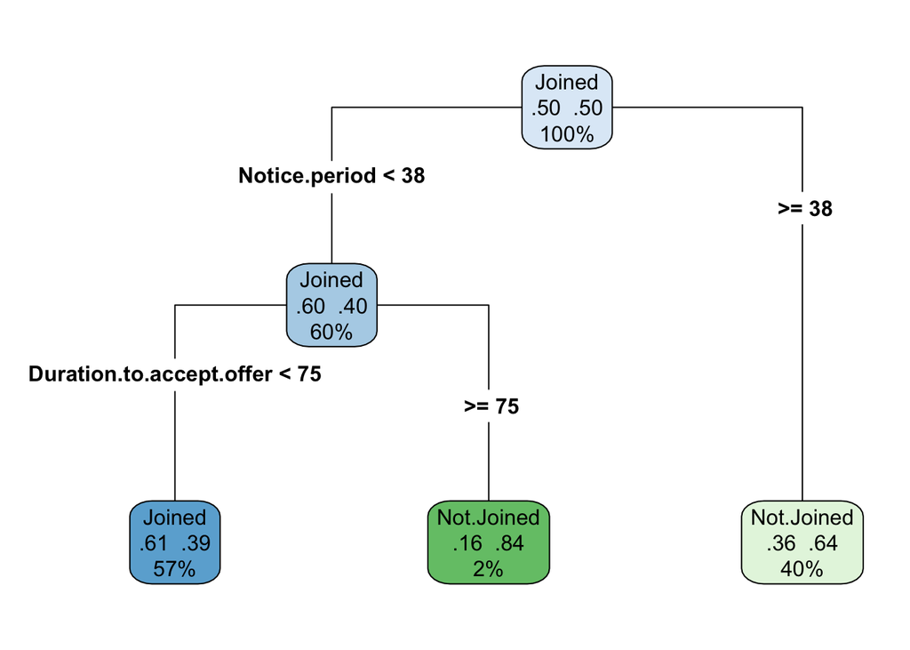

```r
library(rpart.plot)
rpart.plot(dt_caret_model$finalModel, type = 4,extra = 104)
```

## Model Evaluation

### 1. The prediction and confusion Matrix on train data.

The syntax for prediction in caret is almost similar expect the the **type** attribute expects input as **‘raw’** or **‘prob’**. In case of prob, the predicted value holds the probability of both positive and negative class.

```r
#Missing code. May result in error
levels(dt_train_df$Status) <- make.names(levels(factor(dt_train_df$Status)))
caretPredictedClass <- predict(object = dt_caret_model, dt_train_df[,1:12], type = 'raw')
confusionMatrix(caretPredictedClass,dt_train_df$Status)
```

```
## Confusion Matrix and Statistics
##
##             Reference
## Prediction   Joined Not.Joined
##   Joined       4032        595
##   Not.Joined   1819        751
##
##                Accuracy : 0.6646
##                  95% CI : (0.6535, 0.6755)
##     No Information Rate : 0.813
##     P-Value [Acc > NIR] : 1
##
##                   Kappa : 0.183
##
##  Mcnemar's Test P-Value : <2e-16
##
##             Sensitivity : 0.6891
##             Specificity : 0.5579
##          Pos Pred Value : 0.8714
##          Neg Pred Value : 0.2922
##              Prevalence : 0.8130
##          Detection Rate : 0.5602
##    Detection Prevalence : 0.6429
##       Balanced Accuracy : 0.6235
##
##        'Positive' Class : Joined
##
```

### 2. Confusion Matrix on the test data

The **predict** function is used to get the predicted class on the new dataset.

```
## Confusion Matrix and Statistics
##
##             Reference
## Prediction   Joined Not.Joined
##   Joined       1023        157
##   Not.Joined    439        179
##
##                Accuracy : 0.6685
##                  95% CI : (0.6462, 0.6903)
##     No Information Rate : 0.8131
##     P-Value [Acc > NIR] : 1
##
##                   Kappa : 0.1757
##
##  Mcnemar's Test P-Value : <2e-16
##
##             Sensitivity : 0.6997
##             Specificity : 0.5327
##          Pos Pred Value : 0.8669
##          Neg Pred Value : 0.2896
##              Prevalence : 0.8131
##          Detection Rate : 0.5690
##    Detection Prevalence : 0.6563
##       Balanced Accuracy : 0.6162
##
##        'Positive' Class : Joined
##
```

### 3. ROC Plot on the test data

ROCR package can be used to evaluate the model performace on the test data. The same package can also be used to get the model performace on the test data.

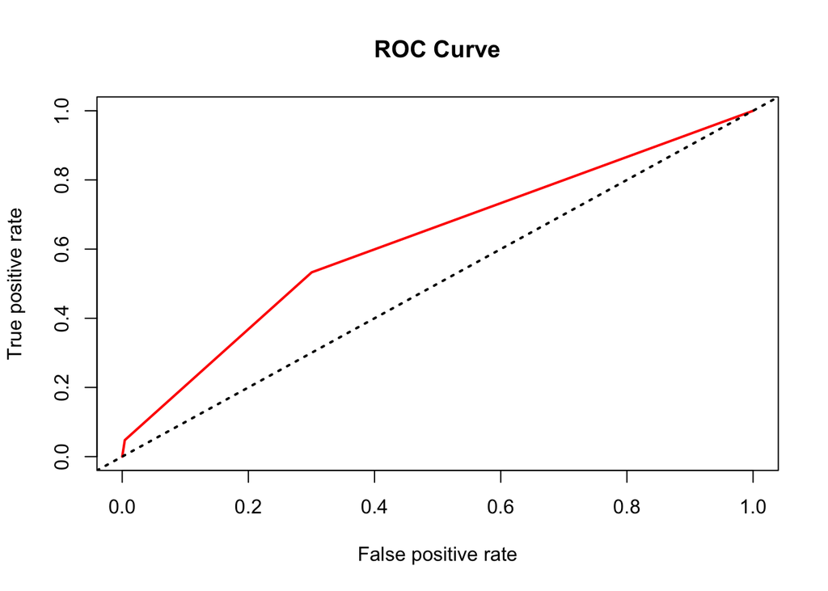

```
## An object of class "performance"
## Slot "x.name":
## [1] "None"
##
## Slot "y.name":
## [1] "Area under the ROC curve"
##
## Slot "alpha.name":
## [1] "none"
##
## Slot "x.values":
## list()
##
## Slot "y.values":
## [[1]]
## [1] 0.6222885
##
##
## Slot "alpha.values":
## list()
```